# Stat542: Linear Regression

### Training Error vs Test Error

For linear regression models, when we add more and more variables, the training error (e.g., RSS or MSE) is always decreasing, but the test error (prediction error on an independent test data) is not necessary decreasing.

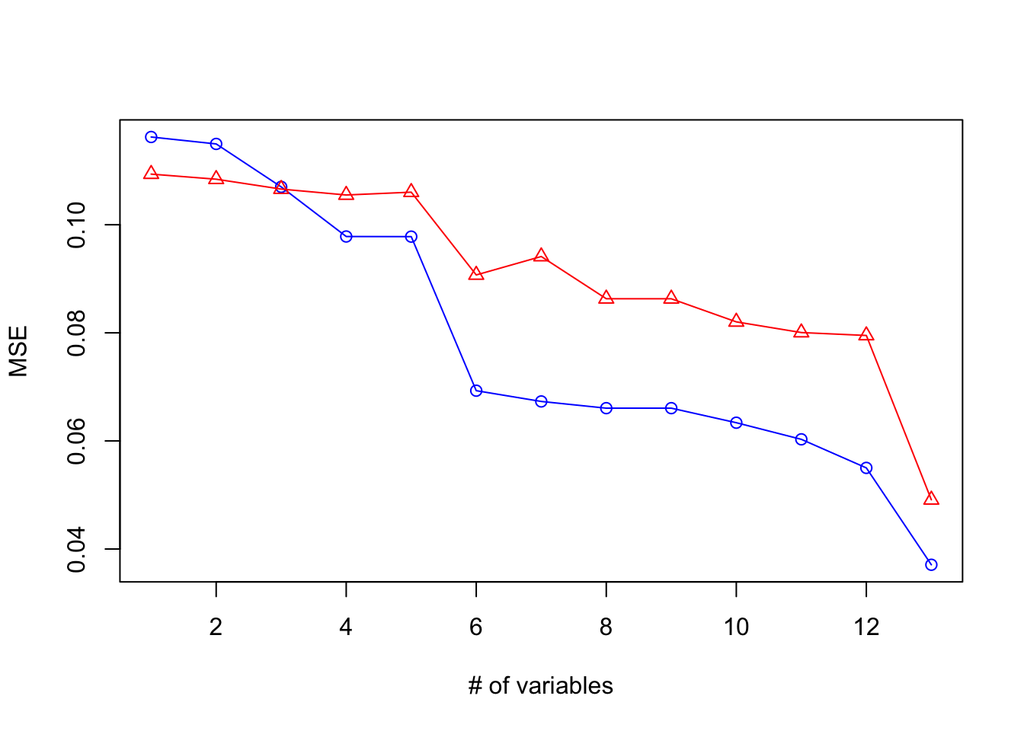

```r
# Go back to the Boston Housing Data
# Divide the data into training and test

# n: sample size
# col 1:p: predictors
# col (p+1): response (in this particular example)
n <- dim(myData)[1]
p <-  dim(myData)[2] - 1

ntrain <-  round(n*0.6)
train.id <-  sample(1:n, ntrain)
train.MSE <-  rep(0, p)
test.MSE <-  rep(0, p)

for(i in 1:p){
  myfit <-  lm(Y ~ ., myData[train.id, c(1:i, (p+1))])
  train.Y <-  myData[train.id, (p+1)]
  train.Y.pred <-  myfit$fitted
  train.MSE[i] <-  mean((train.Y - train.Y.pred)^2)

  test.Y <-  myData[-train.id, (p+1)]
  test.Y.pred <-  predict(myfit, newdata = myData[-train.id, ])
  test.MSE[i] <-  mean((test.Y - test.Y.pred)^2)
}

## type="n": don't plot; just set the plotting region
  plot(c(1, p), range(train.MSE, test.MSE), type="n",
     xlab="# of variables", ylab="MSE")
  points(train.MSE, col = "blue", pch = 1)
  lines(train.MSE, col = "blue", pch = 1)
  points(test.MSE, col = "red", pch = 2)
  lines(test.MSE, col = "red", pch = 2)
```

You can run the code above multiple times. In most cases, the blue line is below the red line (i.e., training error is better than test error), but sometimes, the red line could be below the blue line (i.e., test error is even better than the training error). In each iteration, you would see the blue line is always monotonically decreasing, but red line is not necessarily decreasing. Check the differences between the adjacent terms, which should be always negative for the blue line, but could have some positive terms for the red line.

```r
diff(train.RSS) ## always negative
diff(test.RSS)  ## not always negative
```

[output not shown]

### Understand the LS Coefficient

How to interprete LS coefficients? For example, the coefficient for variable “rm” measures the average change of Y per room, with all other predictors held fixed.

Note that the result from SLR (regression with just one non-intercept predictor) might be different from the one from MLR. SLR suggests that “age” has a significant negative effect on housing price, while MLR suggests the opposite.

Such seemingly contradictory statements are caused by correlations among predictors. In this case, “age” has strong positive correlation with “crim” and “lsat”, two predictors with negative effect on Y; So in the joint model, the coefficient with “age” turns out to be positive, to correct the negative contribution that has already been introduced to the mdoel through the other two predictors.

```r
summary(lm(Y~ age, myData))
```

```
##
## Call:
## lm(formula = Y ~ age, data = myData)
##
## Residuals:
##      Min       1Q   Median       3Q      Max
## -1.17860 -0.18806 -0.03558  0.17234  1.15041
##
## Coefficients:
##              Estimate Std. Error t value Pr(>|t|)
## (Intercept)  3.314134   0.027682  119.72   <2e-16 ***
## age         -0.055252   0.004473  -12.35   <2e-16 ***
## ---
## Signif. codes:  0 '***' 0.001 '**' 0.01 '*' 0.05 '.' 0.1 ' ' 1
##
## Residual standard error: 0.3585 on 504 degrees of freedom
## Multiple R-squared:  0.2324, Adjusted R-squared:  0.2309
## F-statistic: 152.6 on 1 and 504 DF,  p-value: < 2.2e-16
```

```r
round(cor(myData), dig=2)
```

```
##          crim    zn indus  chas   nox    rm   age   dis   rad   tax
## crim     1.00 -0.52  0.74  0.03  0.81 -0.32  0.70 -0.74  0.84  0.81
## zn      -0.52  1.00 -0.66 -0.04 -0.57  0.31 -0.53  0.59 -0.35 -0.31
## indus    0.74 -0.66  1.00  0.08  0.75 -0.43  0.66 -0.73  0.58  0.66
## chas     0.03 -0.04  0.08  1.00  0.08  0.08  0.07 -0.09  0.01 -0.04
## nox      0.81 -0.57  0.75  0.08  1.00 -0.32  0.78 -0.86  0.61  0.67
## rm      -0.32  0.31 -0.43  0.08 -0.32  1.00 -0.28  0.28 -0.21 -0.31
## age      0.70 -0.53  0.66  0.07  0.78 -0.28  1.00 -0.80  0.47  0.54
## dis     -0.74  0.59 -0.73 -0.09 -0.86  0.28 -0.80  1.00 -0.54 -0.60
## rad      0.84 -0.35  0.58  0.01  0.61 -0.21  0.47 -0.54  1.00  0.82
## tax      0.81 -0.31  0.66 -0.04  0.67 -0.31  0.54 -0.60  0.82  1.00
## ptratio  0.45 -0.35  0.45 -0.13  0.34 -0.32  0.38 -0.32  0.40  0.48
## black   -0.48  0.18 -0.33  0.05 -0.38  0.13 -0.29  0.32 -0.41 -0.43
## lstat    0.62 -0.45  0.62 -0.06  0.61 -0.64  0.64 -0.56  0.46  0.53
## Y       -0.57  0.36 -0.55  0.16 -0.52  0.61 -0.48  0.41 -0.43 -0.56
##         ptratio black lstat     Y
## crim       0.45 -0.48  0.62 -0.57
## zn        -0.35  0.18 -0.45  0.36
## indus      0.45 -0.33  0.62 -0.55
## chas      -0.13  0.05 -0.06  0.16
## nox        0.34 -0.38  0.61 -0.52
## rm        -0.32  0.13 -0.64  0.61
## age        0.38 -0.29  0.64 -0.48
## dis       -0.32  0.32 -0.56  0.41
## rad        0.40 -0.41  0.46 -0.43
## tax        0.48 -0.43  0.53 -0.56
## ptratio    1.00 -0.20  0.43 -0.51
## black     -0.20  1.00 -0.36  0.40
## lstat      0.43 -0.36  1.00 -0.83
## Y         -0.51  0.40 -0.83  1.00
```

### Partial Regression Coefficients

Check how to retrieve the LS coefficient for “age” using Algorithm 3.1

```r
y.star <-  lm(Y ~ ., data = subset(myData, select = -age))$res
age.star <-  lm(age ~ ., data = subset(myData, select = -Y))$res
tmpfit <-  lm(y.star ~ age.star)
```

The LS cofficient for “age” (from `lmfit`) is the same as the one from `tmpfit`. The residuals from the two LS models are also the same.

```r
tmpfit$coef
```

```
##  (Intercept)     age.star
## 1.119402e-19 6.403368e-03
```

```r
sum((lmfit$res - tmpfit$res)^2)
```

```
## [1] 2.713755e-29
```

### F-test

Test a single predictor (in this case, F-test = t-test).

```r
lmfit0 <- lm(Y ~ ., data = subset(myData, select = -age))
anova(lmfit0, lmfit)
```

```
## Analysis of Variance Table
##
## Model 1: Y ~ crim + zn + indus + chas + nox + rm + dis + rad + tax + ptratio +
##     black + lstat
## Model 2: Y ~ crim + zn + indus + chas + nox + rm + age + dis + rad + tax +
##     ptratio + black + lstat
##   Res.Df    RSS Df Sum of Sq      F Pr(>F)
## 1    493 19.898
## 2    492 19.828  1  0.069876 1.7338 0.1885
```

Test multiple predictors.

```r
lmfit0 <- lm(Y ~ ., data = myData[, -c(1:3)])
anova(lmfit0, lmfit)
```

```
## Analysis of Variance Table
##
## Model 1: Y ~ chas + nox + rm + age + dis + rad + tax + ptratio + black +
##     lstat
## Model 2: Y ~ crim + zn + indus + chas + nox + rm + age + dis + rad + tax +
##     ptratio + black + lstat
##   Res.Df    RSS Df Sum of Sq      F Pr(>F)
## 1    495 19.929
## 2    492 19.828  3   0.10091 0.8346 0.4753
```

### Collinearity

Check the Car Seat Position Data from `faraway` package.

Car drivers like to adjust the seat position for their own comfort. Car designers would find it helpful to know how different drivers will position the seat depending on their size and age. Researchers at the [HuMoSim laboratory](http://humosim.org/) at the University of Michigan collected data on 38 drivers.

- Age:
- Weight:
- HtShoes: height with shoes in cm
- Ht: height without shoes in cm
- Seated: seated height in cm
- Arm: lower arm length in cm
- Thigh: thigh length in cm
- Leg: lower leg length in cm
- hipcenter: horizontal distance of the midpoint of the hips from a fixed location in the car in mm

The researchers were interested in determining if a relationship exists between hipcenter and the other variables. Due to the high correlations among the predictors, we see high R-square, significant overall F-test, but no individual variables are significant.

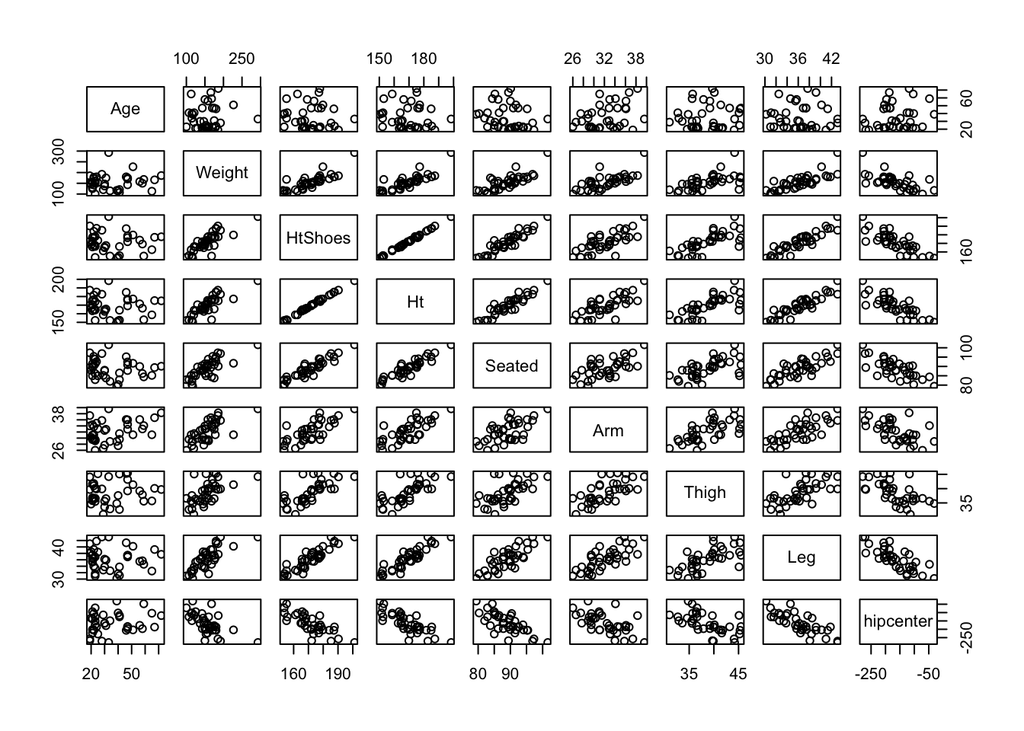

```r
library(faraway)
data(seatpos)
pairs(seatpos)
```

```r
summary(lm(hipcenter ~ . , data=seatpos))
```

```
##
## Call:
## lm(formula = hipcenter ~ ., data = seatpos)
##
## Residuals:
##     Min      1Q  Median      3Q     Max
## -73.827 -22.833  -3.678  25.017  62.337
##
## Coefficients:
##              Estimate Std. Error t value Pr(>|t|)
## (Intercept) 436.43213  166.57162   2.620   0.0138 *
## Age           0.77572    0.57033   1.360   0.1843
## Weight        0.02631    0.33097   0.080   0.9372
## HtShoes      -2.69241    9.75304  -0.276   0.7845
## Ht            0.60134   10.12987   0.059   0.9531
## Seated        0.53375    3.76189   0.142   0.8882
## Arm          -1.32807    3.90020  -0.341   0.7359
## Thigh        -1.14312    2.66002  -0.430   0.6706
## Leg          -6.43905    4.71386  -1.366   0.1824
## ---
## Signif. codes:  0 '***' 0.001 '**' 0.01 '*' 0.05 '.' 0.1 ' ' 1
##
## Residual standard error: 37.72 on 29 degrees of freedom
## Multiple R-squared:  0.6866, Adjusted R-squared:  0.6001
## F-statistic:  7.94 on 8 and 29 DF,  p-value: 1.306e-05
```

```r
## check pairwise correlation
round(cor(seatpos), dig=2)
```

```
##             Age Weight HtShoes    Ht Seated   Arm Thigh   Leg hipcenter
## Age        1.00   0.08   -0.08 -0.09  -0.17  0.36  0.09 -0.04      0.21
## Weight     0.08   1.00    0.83  0.83   0.78  0.70  0.57  0.78     -0.64
## HtShoes   -0.08   0.83    1.00  1.00   0.93  0.75  0.72  0.91     -0.80
## Ht        -0.09   0.83    1.00  1.00   0.93  0.75  0.73  0.91     -0.80
## Seated    -0.17   0.78    0.93  0.93   1.00  0.63  0.61  0.81     -0.73
## Arm        0.36   0.70    0.75  0.75   0.63  1.00  0.67  0.75     -0.59
## Thigh      0.09   0.57    0.72  0.73   0.61  0.67  1.00  0.65     -0.59
## Leg       -0.04   0.78    0.91  0.91   0.81  0.75  0.65  1.00     -0.79
## hipcenter  0.21  -0.64   -0.80 -0.80  -0.73 -0.59 -0.59 -0.79      1.00
```

If we remove some (almost) redundant variables, the LS results make much more sense.

```r
 summary(lm(hipcenter ~ Age + Weight + Ht + Seated, data=seatpos))
 summary(lm(hipcenter ~ Ht, data=seatpos))
```

[output not shown]